# automobile

Exercise-based on a dataset published on Kaggle: https://www.kaggle.com/toramky/automobile-dataset

**Goal:** Finding a model which can accurately predict car price based on some features.

**Solution author's Linkedin profile:** https://bit.ly/3tsOnU3

# 1. Get dataset by Kaggle API

```
There is a parquet file!!!
```

|  | symboling | normalized-losses | make | fuel-type | aspiration | num-of-doors | body-style | drive-wheels | engine-location | wheel-base | ... | engine-size | fuel-system | bore | stroke | compression-ratio | horsepower | peak-rpm | city-mpg | highway-mpg | price |
| --- | --- | --- | --- | --- | --- | --- | --- | --- | --- | --- | --- | --- | --- | --- | --- | --- | --- | --- | --- | --- | --- |
| 0 | 3 | ? | alfa-romero | gas | std | two | convertible | rwd | front | 88.6 | ... | 130 | mpfi | 3.47 | 2.68 | 9.0 | 111 | 5000 | 21 | 27 | 13495 |
| 1 | 3 | ? | alfa-romero | gas | std | two | convertible | rwd | front | 88.6 | ... | 130 | mpfi | 3.47 | 2.68 | 9.0 | 111 | 5000 | 21 | 27 | 16500 |
| 2 | 1 | ? | alfa-romero | gas | std | two | hatchback | rwd | front | 94.5 | ... | 152 | mpfi | 2.68 | 3.47 | 9.0 | 154 | 5000 | 19 | 26 | 16500 |
| 3 | 2 | 164 | audi | gas | std | four | sedan | fwd | front | 99.8 | ... | 109 | mpfi | 3.19 | 3.4 | 10.0 | 102 | 5500 | 24 | 30 | 13950 |
| 4 | 2 | 164 | audi | gas | std | four | sedan | 4wd | front | 99.4 | ... | 136 | mpfi | 3.19 | 3.4 | 8.0 | 115 | 5500 | 18 | 22 | 17450 |

5 rows × 26 columns

# 2. Exploratory Data Analysis

```
(205, 26)
```

**Analysis:** There is nullable columns, BUT there is another character doing the same thing, the "?", as shown in the Kaggle dataset discription, as well as many columns are described as "object" type just because this "?" represanting the nullable values, but this columns are or int64 either float64, this is not real for all "object" type columns but it is reall including for the response variable column. It proves:

- There is null data, so there is the need to delete elements/columns or to add data by interpolation, mean, or mode.
- There is the need to cast some columns.

**Analysis:** Between explicative variables, there are some qualitative variables ("object" type), quantiative ones - discrete (most of them of "int64" type) and continuous (most of them of "float64").

**Analysis:** Afterwards, it was noticed it is necessary to apply data normalization technique to some columns.

```
<class 'pandas.core.frame.DataFrame'>
RangeIndex: 205 entries, 0 to 204
Data columns (total 26 columns):
 #   Column             Non-Null Count  Dtype
---  ------             --------------  -----
 0   symboling          205 non-null    int64
 1   normalized-losses  205 non-null    int64
 2   make               205 non-null    object
 3   fuel-type          205 non-null    object
 4   aspiration         205 non-null    object
 5   num-of-doors       205 non-null    object
 6   body-style         205 non-null    object
 7   drive-wheels       205 non-null    object
 8   engine-location    205 non-null    object
 9   wheel-base         205 non-null    float64
```

[output cut: 18 more lines]

|  | symboling | normalized-losses | wheel-base | length | width | height | curb-weight | engine-size | bore | stroke | compression-ratio | horsepower | peak-rpm | city-mpg | highway-mpg | price |
| --- | --- | --- | --- | --- | --- | --- | --- | --- | --- | --- | --- | --- | --- | --- | --- | --- |
| count | 205.000000 | 205.000000 | 205.000000 | 205.000000 | 205.000000 | 205.000000 | 205.000000 | 205.000000 | 205.000000 | 205.000000 | 205.000000 | 205.000000 | 205.000000 | 205.000000 | 205.000000 | 205.000000 |
| mean | 0.834146 | 122.000000 | 98.756585 | 174.049268 | 65.907805 | 53.724878 | 2555.565854 | 126.907317 | 3.329751 | 3.255423 | 10.142537 | 104.253659 | 5125.369458 | 25.219512 | 30.751220 | 13207.126829 |
| std | 1.245307 | 31.681008 | 6.021776 | 12.337289 | 2.145204 | 2.443522 | 520.680204 | 41.642693 | 0.270844 | 0.313597 | 3.972040 | 39.519219 | 476.979093 | 6.542142 | 6.886443 | 7868.768212 |
| min | -2.000000 | 65.000000 | 86.600000 | 141.100000 | 60.300000 | 47.800000 | 1488.000000 | 61.000000 | 2.540000 | 2.070000 | 7.000000 | 48.000000 | 4150.000000 | 13.000000 | 16.000000 | 5118.000000 |
| 25% | 0.000000 | 101.000000 | 94.500000 | 166.300000 | 64.100000 | 52.000000 | 2145.000000 | 97.000000 | 3.150000 | 3.110000 | 8.600000 | 70.000000 | 4800.000000 | 19.000000 | 25.000000 | 7788.000000 |
| 50% | 1.000000 | 122.000000 | 97.000000 | 173.200000 | 65.500000 | 54.100000 | 2414.000000 | 120.000000 | 3.310000 | 3.290000 | 9.000000 | 95.000000 | 5200.000000 | 24.000000 | 30.000000 | 10595.000000 |
| 75% | 2.000000 | 137.000000 | 102.400000 | 183.100000 | 66.900000 | 55.500000 | 2935.000000 | 141.000000 | 3.580000 | 3.410000 | 9.400000 | 116.000000 | 5500.000000 | 30.000000 | 34.000000 | 16500.000000 |
| max | 3.000000 | 256.000000 | 120.900000 | 208.100000 | 72.300000 | 59.800000 | 4066.000000 | 326.000000 | 3.940000 | 4.170000 | 23.000000 | 288.000000 | 6600.000000 | 49.000000 | 54.000000 | 45400.000000 |

**Analysis:** There is some skewed data, it can be seen on some columns histogram and on theis boxplots below.

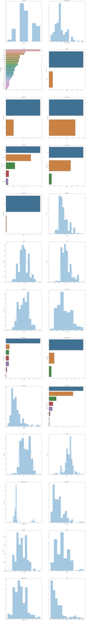

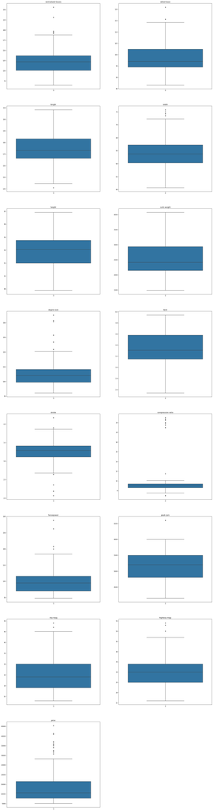

**Analysis:** The heatmap for Pearson correlation table below proves there is a diversity of correlation level, according to Evans classification, Evans (1996, also http://leg.ufpr.br/~silvia/CE003/node74.html, on Brazilian portuguese)

```
<function matplotlib.pyplot.close(fig=None)>
```

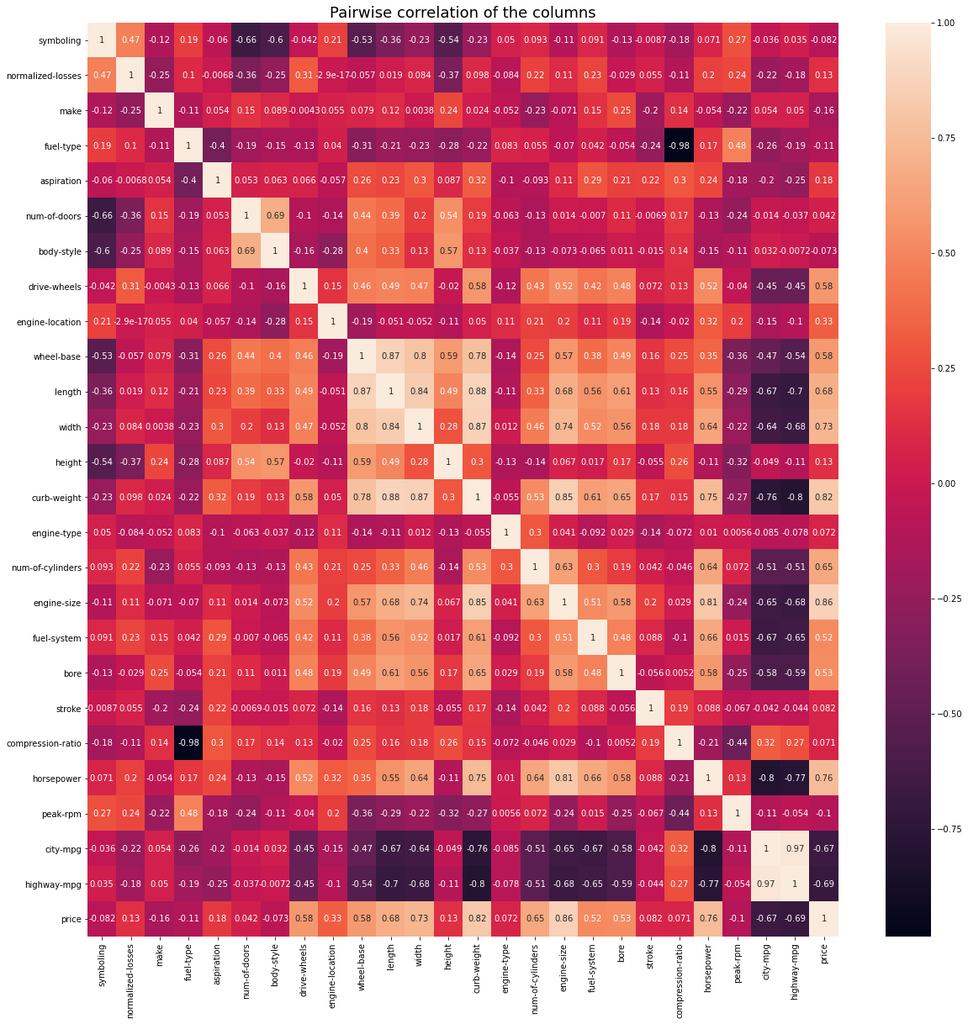

**Analysis:** In pairwise relationships graphics below, it's seen that the strongest object column delivers a small considerable division between classes of the other variables.

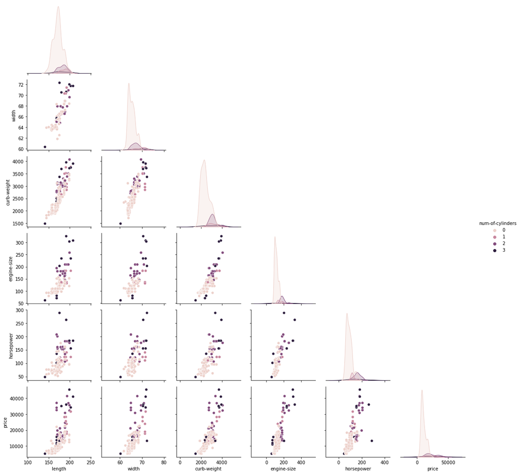

# 3. Model training and testing

## 3.1. No treatment applied on models - With skewed data and no attribute selection

**Explicative variables**

|  | symboling | normalized-losses | make | fuel-type | aspiration | num-of-doors | body-style | drive-wheels | engine-location | wheel-base | ... | num-of-cylinders | engine-size | fuel-system | bore | stroke | compression-ratio | horsepower | peak-rpm | city-mpg | highway-mpg |
| --- | --- | --- | --- | --- | --- | --- | --- | --- | --- | --- | --- | --- | --- | --- | --- | --- | --- | --- | --- | --- | --- |
| 0 | 3 | 122 | 0 | 1 | 0 | 0 | 0 | 2 | 0 | 88.6 | ... | 0 | 130 | 5 | 3.47 | 2.68 | 9.0 | 111 | 5000.0 | 21 | 27 |
| 1 | 3 | 122 | 0 | 1 | 0 | 0 | 0 | 2 | 0 | 88.6 | ... | 0 | 130 | 5 | 3.47 | 2.68 | 9.0 | 111 | 5000.0 | 21 | 27 |
| 2 | 1 | 122 | 0 | 1 | 0 | 0 | 2 | 2 | 0 | 94.5 | ... | 2 | 152 | 5 | 2.68 | 3.47 | 9.0 | 154 | 5000.0 | 19 | 26 |
| 3 | 2 | 164 | 1 | 1 | 0 | 1 | 3 | 1 | 0 | 99.8 | ... | 0 | 109 | 5 | 3.19 | 3.40 | 10.0 | 102 | 5500.0 | 24 | 30 |
| 4 | 2 | 164 | 1 | 1 | 0 | 1 | 3 | 0 | 0 | 99.4 | ... | 1 | 136 | 5 | 3.19 | 3.40 | 8.0 | 115 | 5500.0 | 18 | 22 |

5 rows × 25 columns

**Response variable**

|  | price |
| --- | --- |
| 0 | 13495 |
| 1 | 16500 |
| 2 | 16500 |
| 3 | 13950 |
| 4 | 17450 |

```
MAE mean:
	LinearRegression         : 2282.88927
	Lasso                    : 2275.74097
	RandomForestRegressor    : 1700.23440
	GradientBoostingRegressor: 1704.69821
	Ridge                    : 2225.11044
	KNeighborsRegressor      : 2339.96731
	DecisionTreeRegressor    : 2170.36613
	PLSRegression            : 2373.03395
	ElasticNet               : 2191.24786
	XGBRegressor             : 1796.92623
	XGBRFRegressor           : 1779.58029
MSE mean:
	LinearRegression         : 11293519.04439
	Lasso                    : 11213042.18868
	RandomForestRegressor    : 7601853.31652
	GradientBoostingRegressor: 7806473.07339
	Ridge                    : 10741436.55392
	KNeighborsRegressor      : 13749804.12675
	DecisionTreeRegressor    : 12590856.83602
	PLSRegression            : 11821551.88269
	ElasticNet               : 10987393.81347
	XGBRegressor             : 9759346.10859
	XGBRFRegressor           : 9017151.82214
R2 score mean:
	LinearRegression         : 0.80145
	Lasso                    : 0.80278
	RandomForestRegressor    : 0.86188
	GradientBoostingRegressor: 0.85962
	Ridge                    : 0.81046
	KNeighborsRegressor      : 0.76867
	DecisionTreeRegressor    : 0.77466
	PLSRegression            : 0.79328
	ElasticNet               : 0.81161
	XGBRegressor             : 0.82212
	XGBRFRegressor           : 0.83682
Confidence interval - R2 Score - LinearRegression              : (0.764819900922077, 0.8380900858349246)
Confidence interval - R2 Score - Lasso                         : (0.7664618505918239, 0.8390968230888212)
Confidence interval - R2 Score - RandomForestRegressor         : (0.8268613351121201, 0.8969082686282417)
Confidence interval - R2 Score - GradientBoostingRegressor     : (0.8268206083749827, 0.8924196098873867)
Confidence interval - R2 Score - Ridge                         : (0.7759727072485816, 0.8449383508242434)
Confidence interval - R2 Score - KNeighborsRegressor           : (0.7437511537488586, 0.7935911172488479)
Confidence interval - R2 Score - DecisionTreeRegressor         : (0.7176192609868226, 0.8316930256072623)
Confidence interval - R2 Score - PLSRegression                 : (0.7613599920183562, 0.8252007721541588)
Confidence interval - R2 Score - ElasticNet                    : (0.7888554657896084, 0.8343649433330508)
Confidence interval - R2 Score - XGBRegressor                  : (0.7748238294948265, 0.8694186784197434)
Confidence interval - R2 Score - XGBRFRegressor                : (0.7972400883093372, 0.8763944254820145)
```

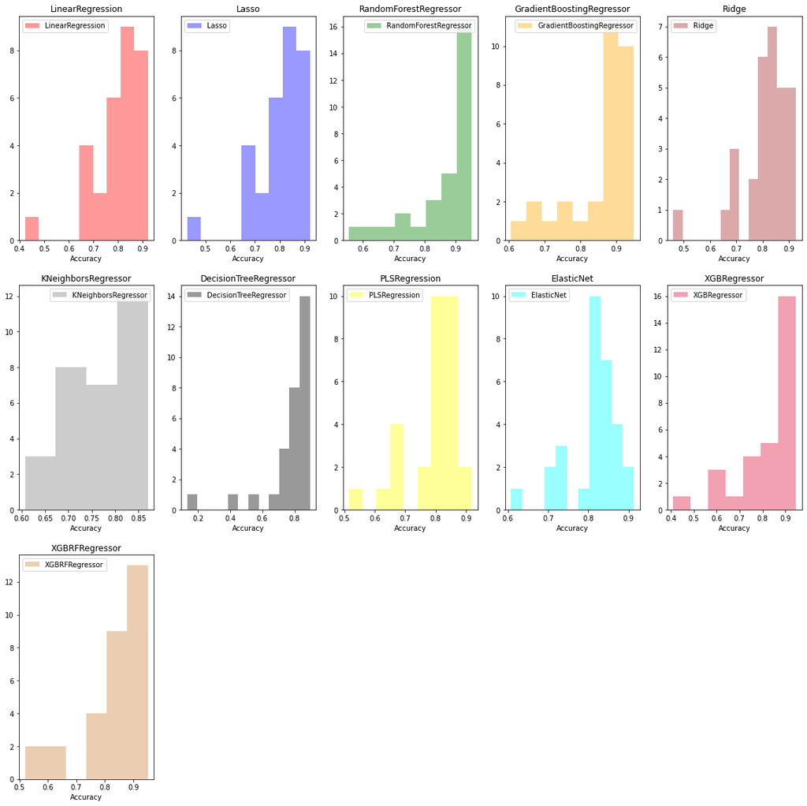

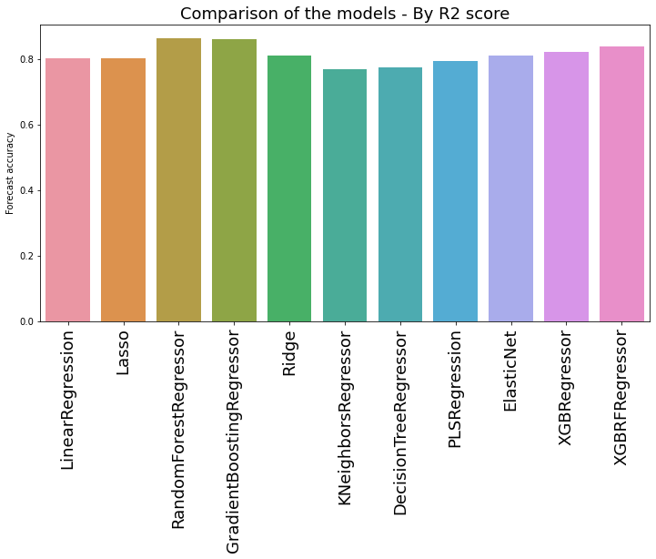

## 3.2. Oversampling and Undersampling Technique - With skewed data, no attribute selection, normalized data with Standard Scaler, dataset size for test 30%

**Analysis:** on exploratory data analysis, it was seen that classes of some important explicative variables ("drive-wheels" - 58%, "engine-location" - 33%, "num-of-cylinders" - 65%, "fuel-system" - 52%) are unbalanced between their classes. So, Oversampling and Undersampling technique were choosen to solve this problem and a satisfactory result was achieved applying them just on the "num-of-cylinders" variable. The Oversampling (RandomOverSampler) and Undersampling (RepeatedEditedNearestNeighbours) techniques choosen in this project are the same used in the "Credit Card" classfication project which is in this same Github repository, and on that ocasion they showed a satisfactory performance improvement for the algorithms.

```
Num-of-cilinders variable's classes distribution before applying Oversampling and Undersampling techniques: (array([0, 1, 2, 3]), array([159,  11,  24,  11], dtype=int64))
num-of-cilinders variable's classes distribution after applying Oversampling and Undersampling techniques:(array([0, 1, 2, 3]), array([119, 119, 119, 119], dtype=int64))
MAE mean:
	LinearRegression         : 2123.42562
	Lasso                    : 2116.56822
	RandomForestRegressor    : 338.87497
	GradientBoostingRegressor: 455.57772
	Ridge                    : 2081.85967
	KNeighborsRegressor      : 687.63744
	DecisionTreeRegressor    : 307.06089
	PLSRegression            : 3201.43449
	ElasticNet               : 2684.40473
	XGBRegressor             : 556.32753
	XGBRFRegressor           : 559.69365
MSE mean:
	LinearRegression         : 7457682.60113
	Lasso                    : 7439945.39634
	RandomForestRegressor    : 650335.15295
	GradientBoostingRegressor: 499065.63307
	Ridge                    : 7473510.21810
	KNeighborsRegressor      : 2270687.52234
	DecisionTreeRegressor    : 856394.33685
	PLSRegression            : 17638782.79092
	ElasticNet               : 13467537.36900
	XGBRegressor             : 746664.09265
	XGBRFRegressor           : 773152.34314
R2 score mean:
	LinearRegression         : 0.94158
	Lasso                    : 0.94173
	RandomForestRegressor    : 0.99490
	GradientBoostingRegressor: 0.99608
	Ridge                    : 0.94148
	KNeighborsRegressor      : 0.98230
	DecisionTreeRegressor    : 0.99327
	PLSRegression            : 0.86153
	ElasticNet               : 0.89457
	XGBRegressor             : 0.99416
	XGBRFRegressor           : 0.99391
Confidence interval - R2 Score - LinearRegression              : (0.9389862166737776, 0.9441829632767661)
Confidence interval - R2 Score - Lasso                         : (0.9391013543608162, 0.9443495970650515)
Confidence interval - R2 Score - RandomForestRegressor         : (0.9940360283282452, 0.9957650852978319)
Confidence interval - R2 Score - GradientBoostingRegressor     : (0.9956677294193615, 0.9964898227068105)
Confidence interval - R2 Score - Ridge                         : (0.9386257240839938, 0.9443413594759856)
Confidence interval - R2 Score - KNeighborsRegressor           : (0.9778553211974658, 0.9867368694967759)
Confidence interval - R2 Score - DecisionTreeRegressor         : (0.9917940881173714, 0.9947496229838088)
Confidence interval - R2 Score - PLSRegression                 : (0.8525294776139724, 0.8705266588153521)
Confidence interval - R2 Score - ElasticNet                    : (0.8897021938230594, 0.8994404234773761)
Confidence interval - R2 Score - XGBRegressor                  : (0.993548456306507, 0.9947774020101136)
Confidence interval - R2 Score - XGBRFRegressor                : (0.993103259306685, 0.9947217124782085)
```

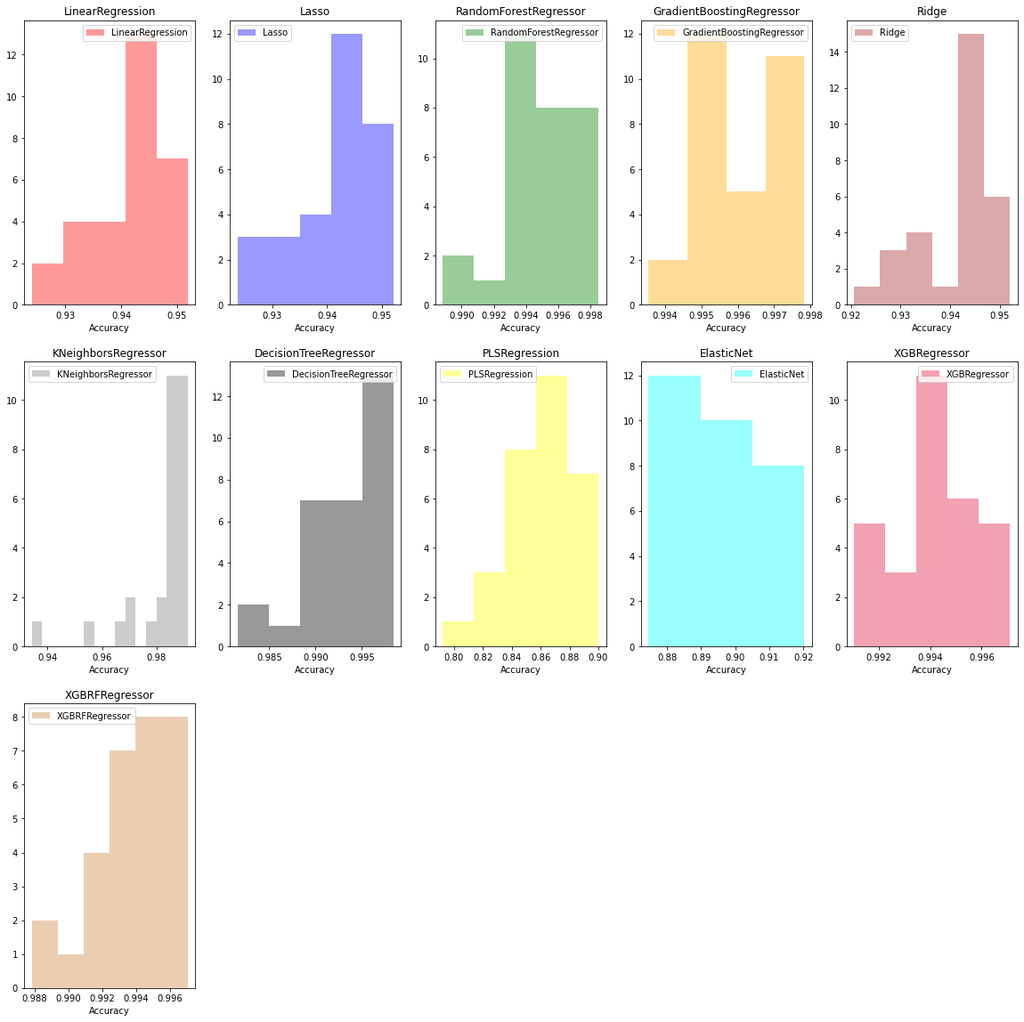

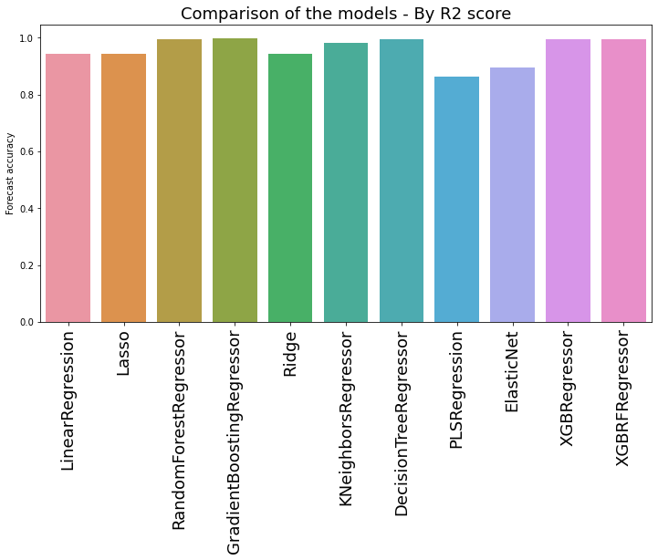